# 重賞レース予測レポート【毎時自動更新中】

作成日時: 2025/07/20 13:04:42

☞ [マニュアル(pdf)](https://ryutoro-galois.github.io/keiba-predictor/manual/manual.pdf)

☞ 過去5年の同一レース結果: [2024年](https://ryutoro-galois.github.io/keiba-predictor/report/PredResult_2024y_raceDate_20240713_20240714.html), [2023年](https://ryutoro-galois.github.io/keiba-predictor/report/PredResult_2023y_raceDate_20230715_20230716.html), [2022年](https://ryutoro-galois.github.io/keiba-predictor/report/PredResult_2022y_raceDate_20220716_20220717.html), [2021年](https://ryutoro-galois.github.io/keiba-predictor/report/PredResult_2021y_raceDate_20210717_20210718.html), [2020年](https://ryutoro-galois.github.io/keiba-predictor/report/PredResult_2020y_raceDate_20200718_20200719.html)

☞ 過去4週間の別レース結果: [1週前(7/13)](https://ryutoro-galois.github.io/keiba-predictor/report/PredResult_2025y_raceDate_20250713_20250713.html), [2週前(7/6)](https://ryutoro-galois.github.io/keiba-predictor/report/PredResult_2025y_raceDate_20250706_20250706.html), [3週前(6/29)](https://ryutoro-galois.github.io/keiba-predictor/report/PredResult_2025y_raceDate_20250629_20250629.html), [4週前(6/22)](https://ryutoro-galois.github.io/keiba-predictor/report/PredResult_2025y_raceDate_20250622_20250622.html)

☞ netkeiba: [小倉記念(GⅢ)](https://race.netkeiba.com/race/shutuba.html?race_id=202510020811&rf=race_list), [函館2歳ステークス(GⅢ)](https://race.netkeiba.com/race/shutuba.html?race_id=202502011211&rf=race_list)

## 0. 推し馬予測 (AI予測)

### 【小倉記念(GⅢ) 2025/07/20(日)】

- 本命(◎): 1-3着内確率(勝負強さ)が1位の馬
- 対抗(◯): 1-3着内確率が2-N位(20%程度以上)の中で予測タイムが最も速い馬
- 3番手(▲): 1-3着内確率が2-N位(20%程度以上)のでダークホース確率が最も高い馬
- 穴: ダークホース確率が上位1-M位(40%程度以上)の中で1-3着内確率が最も高い馬

| 推し馬 | 枠番 | 馬番 | 人気 | オッズ | 馬名 | 騎手 | 調教師 | 予測タイム(sec) | 1_順位 | 1-3着内確率(%) | 2_順位 | ﾀﾞｰｸﾎｰｽ確率(%) | 3_順位 |
| --- | --- | --- | --- | --- | --- | --- | --- | --- | --- | --- | --- | --- | --- |
| 本命(◎) | 8 | 16 | 2 | 5.7 | ディープモンスター | 北村友一 | 池江泰寿 | 116.9 | 2 | 33.9 | 1 | 0.4 | 15 |
| 対抗(◯) | 2 | 4 | 1 | 4.9 | メリオーレム | 川田将雅 | 友道康夫 | 116.9 | 2 | 23.2 | 2 | 0.6 | 14 |
| 3番手(▲) | 4 | 7 | 5 | 9.7 | オールセインツ | 酒井学 | 友道康夫 | 125.5 | 8 | 20.2 | 3 | 1.6 | 11 |
| 穴 | 3 | 5 | 10 | 17.2 | マイネルメモリー | 田口貫太 | 宮徹 | 116.9 | 2 | 13.7 | 8 | 58.8 | 1 |

### 【函館2歳ステークス(GⅢ) 2025/07/20(日)】

- 本命(◎): 1-3着内確率(勝負強さ)が1位の馬
- 対抗(◯): 1-3着内確率が2-N位(20%程度以上)の中で予測タイムが最も速い馬
- 3番手(▲): 1-3着内確率が2-N位(20%程度以上)のでダークホース確率が最も高い馬
- 穴: ダークホース確率が上位1-M位(40%程度以上)の中で1-3着内確率が最も高い馬

| 推し馬 | 枠番 | 馬番 | 人気 | オッズ | 馬名 | 騎手 | 調教師 | 予測タイム(sec) | 1_順位 | 1-3着内確率(%) | 2_順位 | ﾀﾞｰｸﾎｰｽ確率(%) | 3_順位 |
| --- | --- | --- | --- | --- | --- | --- | --- | --- | --- | --- | --- | --- | --- |
| 本命(◎) | 6 | 8 | 2 | 3.0 | ブラックチャリス | 浜中俊 | 武幸四郎 | 75.5 | 2.0 | 49.1 | 1 | 0.4 | 12 |
| 対抗(◯) | 4 | 4 | 3 | 8.1 | タガノアラリア | 斎藤新 | 西園翔 | 75.8 | 12.0 | 20.2 | 2 | 1.8 | 10 |
| 3番手(▲) | 3 | 3 | 6 | 13.6 | エスカレイト | 丹内祐次 | 小栗実 | 75.6 | 3.5 | 17.7 | 5 | 2.0 | 7 |
| 穴 | 1 | 1 | 11 | 61.1 | ノアールビーナス | 川又賢治 | 杉山佳明 | 75.6 | 3.5 | 8.0 | 10 | 43.1 | 1 |

## 1. 予測チャート (タイム/勝負強さ)

### 【小倉記念(GⅢ)】

2025/07/20(日), 10_小倉, 芝右2000m

[interactive chart not shown]

### 【函館2歳ステークス(GⅢ)】

2025/07/20(日), 02_函館, 芝右1200m

[interactive chart not shown]

## 2. オッズモニタリング (毎時)

### 【小倉記念】

[interactive chart not shown]

### 【函館2歳ステークス】

[interactive chart not shown]

## 3. 出馬表

### 【小倉記念 2025/07/20(日) 】

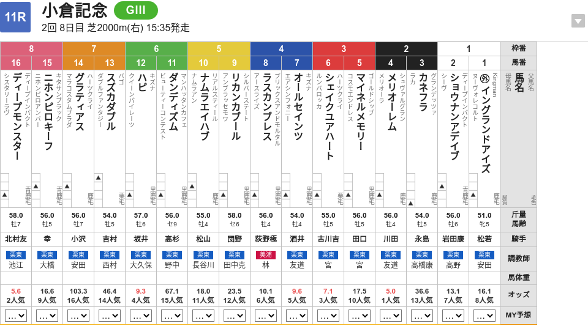

### 【函館2歳ステークス 2025/07/20(日) 】

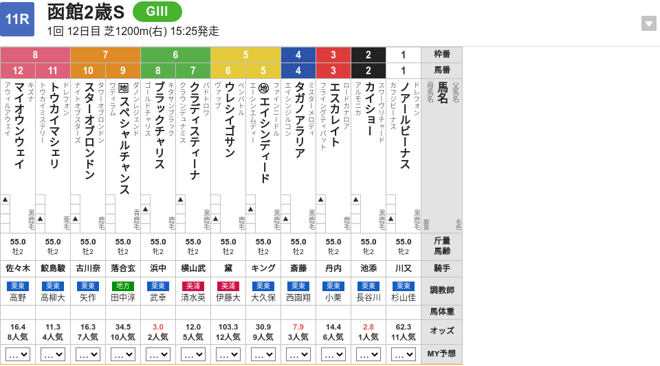

## 4. 単勝予測結果

### 【小倉記念(GⅢ) 2025/07/20(日)】

| 枠番 | 馬番 | 人気 | オッズ | 馬名 | 騎手 | 調教師 | 予測タイム(sec) | 1_順位 | 1-3着内確率(%) | 2_順位 | ﾀﾞｰｸﾎｰｽ確率(%) | 3_順位 |
| --- | --- | --- | --- | --- | --- | --- | --- | --- | --- | --- | --- | --- |
| 1 | 1 | 8 | 16.0 | イングランドアイズ | 松若風馬 | 安田翔伍 | 128.5 | 13 | 6.7 | 11 | 1.5 | 13 |
| 1 | 2 | 7 | 13.2 | ショウナンアデイブ | 岩田康誠 | 高野友和 | 121.1 | 5 | 15.6 | 6 | 1.7 | 10 |
| 2 | 3 | 13 | 36.0 | カネフラ | 永島まなみ | 高橋康之 | 131.0 | 16 | 3.0 | 13 | 13.4 | 8 |
| 2 | 4 | 1 | 4.9 | メリオーレム | 川田将雅 | 友道康夫 | 116.9 | 2 | 23.2 | 2 | 0.6 | 14 |
| 3 | 5 | 10 | 17.2 | マイネルメモリー | 田口貫太 | 宮徹 | 116.9 | 2 | 13.7 | 8 | 58.8 | 1 |
| 3 | 6 | 3 | 7.2 | シェイクユアハート | 古川吉洋 | 宮徹 | 127.1 | 11 | 16.1 | 5 | 0.4 | 16 |
| 4 | 7 | 5 | 9.7 | オールセインツ | 酒井学 | 友道康夫 | 125.5 | 8 | 20.2 | 3 | 1.6 | 11 |
| 4 | 8 | 6 | 10.0 | ラスカンブレス | 荻野極 | 林徹 | 125.6 | 9 | 19.7 | 4 | 1.8 | 9 |
| 5 | 9 | 12 | 23.5 | リカンカブール | 団野大成 | 田中克典 | 127.9 | 12 | 2.1 | 14 | 27.7 | 3 |
| 5 | 10 | 11 | 17.5 | ナムラエイハブ | 松山弘平 | 長谷川浩大 | 125.7 | 10 | 8.0 | 10 | 43.5 | 2 |

[output cut: 6 more lines]

### 【函館2歳ステークス(GⅢ) 2025/07/20(日)】

| 枠番 | 馬番 | 人気 | オッズ | 馬名 | 騎手 | 調教師 | 予測タイム(sec) | 1_順位 | 1-3着内確率(%) | 2_順位 | ﾀﾞｰｸﾎｰｽ確率(%) | 3_順位 |
| --- | --- | --- | --- | --- | --- | --- | --- | --- | --- | --- | --- | --- |
| 1 | 1 | 11 | 61.1 | ノアールビーナス | 川又賢治 | 杉山佳明 | 75.6 | 3.5 | 8.0 | 10 | 43.1 | 1 |
| 2 | 2 | 1 | 2.8 | カイショー | 池添謙一 | 長谷川浩大 | 69.2 | 1.0 | 18.1 | 4 | 0.5 | 11 |
| 3 | 3 | 6 | 13.6 | エスカレイト | 丹内祐次 | 小栗実 | 75.6 | 3.5 | 17.7 | 5 | 2.0 | 7 |
| 4 | 4 | 3 | 8.1 | タガノアラリア | 斎藤新 | 西園翔 | 75.8 | 12.0 | 20.2 | 2 | 1.8 | 10 |
| 5 | 5 | 9 | 31.2 | エイシンディード | Ｒ．キング | 大久保龍志 | 75.8 | 9.0 | 8.1 | 9 | 35.3 | 4 |
| 5 | 6 | 12 | 101.7 | ウレシイゴサン | 黛弘人 | 伊藤大士 | 75.8 | 9.0 | 7.0 | 11 | 37.0 | 3 |
| 6 | 7 | 5 | 11.8 | クラディスティーナ | 横山武史 | 清水英克 | 75.7 | 6.0 | 17.3 | 6 | 1.8 | 9 |
| 6 | 8 | 2 | 3.0 | ブラックチャリス | 浜中俊 | 武幸四郎 | 75.5 | 2.0 | 49.1 | 1 | 0.4 | 12 |
| 7 | 9 | 10 | 34.8 | スペシャルチャンス | 落合玄太 | 田中淳司 | 75.8 | 9.0 | 6.9 | 12 | 37.6 | 2 |
| 7 | 10 | 8 | 16.2 | スターオブロンドン | 古川奈穂 | 矢作芳人 | 75.8 | 9.0 | 9.4 | 8 | 29.3 | 5 |

[output cut: 2 more lines]

## 5. 人気と着順の乖離率推移

### 【小倉記念_1990y_2019y】

[interactive chart not shown]

### 【函館2歳ステークス_2001y_2019y】

[interactive chart not shown]

### 【小倉記念_1990y_2019y】

| No | 開催年 | 不整合率(%) | 頭数 | 人気別着順(1-3位) | 人気別着順(全体) |
| --- | --- | --- | --- | --- | --- |
| 30 | 2019 | 46.0 | 13頭 | 1-6-5 | 1\|6\|5\|4\|8\|10\|3\|7\|12\|11\|2\|13\|9 |
| 29 | 2018 | 16.8 | 12頭 | 1-2-5 | 1\|2\|5\|8\|6\|12\|3\|9\|10\|7\|11\|4 |
| 28 | 2017 | 48.2 | 13頭 | 4-2-6 | 4\|2\|6\|8\|9\|5\|13\|1\|7\|11\|3\|12\|10 |
| 27 | 2016 | 36.4 | 12頭 | 11-4-6 | 11\|4\|6\|1\|5\|8\|2\|9\|3\|7\|10\|12 |
| 26 | 2015 | 38.5 | 17頭 | 6-2-3 | 6\|2\|3\|8\|1\|4\|12\|10\|15\|7\|9\|5\|13\|17\|16\|11\|14 |
| 25 | 2014 | 51.9 | 14頭 | 3-6-2 | 3\|6\|2\|4\|9\|1\|5\|11\|7\|12\|14\|10\|8\|13 |
| 24 | 2013 | 41.2 | 15頭 | 3-5-1 | 3\|5\|1\|4\|6\|2\|12\|15\|10\|7\|8\|13\|9\|14\|11 |
| 23 | 2012 | 36.3 | 12頭 | 3-1-9 | 3\|1\|9\|2\|8\|7\|4\|10\|11\|5\|6\|12 |
| 22 | 2011 | 38.4 | 18頭 | 4-15-8 | 4\|15\|8\|5\|13\|1\|10\|16\|6\|2\|12\|14\|18\|3\|7\|17\|9\|11 |
| 21 | 2010 | 26.3 | 17頭 | 9-4-1 | 9\|4\|1\|2\|13\|12\|3\|5\|10\|15\|7\|11\|6\|17\|16\|8\|14 |

[output cut: 20 more lines]

### 【函館2歳ステークス_2001y_2019y】

| No | 開催年 | 不整合率(%) | 頭数 | 人気別着順(1-3位) | 人気別着順(全体) |
| --- | --- | --- | --- | --- | --- |
| 19 | 2019 | 48.1 | 15頭 | 4-2-11 | 4\|2\|11\|3\|1\|8\|13\|9\|15\|5\|12\|7\|10\|6\|14 |
| 18 | 2018 | 45.7 | 16頭 | 2-7-3 | 2\|7\|3\|9\|6\|12\|11\|4\|1\|8\|13\|15\|16\|5\|14\|10 |
| 17 | 2017 | 28.9 | 15頭 | 1-12-4 | 1\|12\|4\|8\|5\|2\|7\|10\|6\|9\|14\|3\|13\|15\|11 |
| 16 | 2016 | 22.8 | 16頭 | 2-1-13 | 2\|1\|13\|8\|3\|6\|4\|5\|14\|10\|9\|11\|12\|15\|7\|16 |
| 15 | 2015 | 32.0 | 16頭 | 1-3-10 | 1\|3\|10\|12\|6\|4\|2\|11\|13\|9\|7\|15\|8\|5\|14\|16 |
| 14 | 2014 | 41.3 | 16頭 | 4-11-2 | 4\|11\|2\|12\|1\|6\|7\|5\|8\|3\|15\|10\|13\|16\|14\|9 |
| 13 | 2013 | 30.6 | 16頭 | 1-9-8 | 1\|9\|8\|2\|5\|12\|10\|11\|15\|14\|7\|4\|6\|16\|13\|3 |
| 12 | 2012 | 49.9 | 16頭 | 3-5-2 | 3\|5\|2\|14\|1\|8\|6\|7\|11\|9\|4\|12\|13\|16\|10\|15 |
| 11 | 2011 | 40.6 | 13頭 | 2-5-4 | 2\|5\|4\|1\|7\|11\|6\|9\|10\|8\|3\|12\|13 |
| 10 | 2010 | 24.0 | 13頭 | 2-1-3 | 2\|1\|3\|6\|5\|12\|9\|8\|4\|11\|10\|13\|7 |

[output cut: 9 more lines]

## 6. 1-3番人気馬の着順分類予測

### 【小倉記念】

| 分類 | 凡例 | 発生確率(%) | 当該レース | 当該レースランク | 直近1年間 |
| --- | --- | --- | --- | --- | --- |
| 1: 1番人気のみ (1_pop1) | 1 \| * \| * | 18.3 | 0.71 | 0.98 | 0.37 |
| 4: 1,2番人気のみ (4_pop12) | 1 \| 2 \| * | 16.6 | 1.93 | 1.63 | 0.00 |
| 8: 1,2,3番人気すべて着外 (8_darkhorse) | * \| * \| * | 14.6 | 0.85 | 0.86 | 0.00 |
| 5: 1,3番人気のみ (5_pop13) | 1 \| 3 \| * | 14.2 | 0.99 | 1.19 | 0.00 |
| 6: 2,3番人気のみ (6_pop23) | 2 \| 3 \| * | 9.9 | 0.87 | 0.83 | 0.00 |
| 2: 2番人気のみ (2_pop2) | 2 \| * \| * | 9.8 | 1.14 | 0.48 | 0.20 |
| 3: 3番人気のみ (3_pop3) | 3 \| * \| * | 9.5 | 1.67 | 2.79 | 0.00 |
| 7: 1,2,3番人気すべて着内 (7_pop123) | 1 \| 2 \| 3 | 7.1 | 0.83 | 1.04 | 0.00 |

### 【函館2歳ステークス】

| 分類 | 凡例 | 発生確率(%) | 当該レース | 当該レースランク | 直近1年間 |
| --- | --- | --- | --- | --- | --- |
| 1: 1番人気のみ (1_pop1) | 1 \| * \| * | 16.8 | 2.02 | 0.90 | 0.34 |
| 4: 1,2番人気のみ (4_pop12) | 1 \| 2 \| * | 16.2 | 1.30 | 1.59 | 0.00 |
| 8: 1,2,3番人気すべて着外 (8_darkhorse) | * \| * \| * | 14.3 | 0.86 | 0.85 | 0.00 |
| 5: 1,3番人気のみ (5_pop13) | 1 \| 3 \| * | 13.9 | 1.67 | 1.17 | 0.00 |
| 2: 2番人気のみ (2_pop2) | 2 \| * \| * | 12.9 | 0.34 | 0.64 | 0.26 |
| 6: 2,3番人気のみ (6_pop23) | 2 \| 3 \| * | 9.7 | 0.78 | 0.82 | 0.00 |
| 3: 3番人気のみ (3_pop3) | 3 \| * \| * | 9.3 | 0.00 | 2.74 | 0.00 |
| 7: 1,2,3番人気すべて着内 (7_pop123) | 1 \| 2 \| 3 | 6.9 | 1.64 | 1.01 | 0.00 |

## 7. 3連複予測結果

### 【小倉記念(GⅢ) 2025/07/20(日)】

| 分類 | 馬番 | 枠番 | 人気 | 平均予測タイム(sec) | 1-3着内確率(%) | ﾀﾞｰｸﾎｰｽ確率(%) | 馬名 | 騎手 | 調教師 |
| --- | --- | --- | --- | --- | --- | --- | --- | --- | --- |
| 4: 1,2番人気のみ (4_pop12) | 4-16-7 | 2-8-4 | 1-2-5 | 119.77 | 1.59 | 0.00 | メリオーレム \| ディープモンスター \| オールセインツ | 川田将雅 \| 北村友一 \| 酒井学 | 友道康夫 \| 池江泰寿 \| 友道康夫 |
| 4: 1,2番人気のみ (4_pop12) | 4-16-8 | 2-8-4 | 1-2-6 | 119.80 | 1.54 | 0.00 | メリオーレム \| ディープモンスター \| ラスカンブレス | 川田将雅 \| 北村友一 \| 荻野極 | 友道康夫 \| 池江泰寿 \| 林徹 |
| 2: 2番人気のみ (2_pop2) | 16-7-8 | 8-4-4 | 2-5-6 | 122.67 | 1.35 | 0.00 | ディープモンスター \| オールセインツ \| ラスカンブレス | 北村友一 \| 酒井学 \| 荻野極 | 池江泰寿 \| 友道康夫 \| 林徹 |
| 7: 1,2,3番人気すべて着内 (7_pop123) | 4-16-6 | 2-8-3 | 1-2-3 | 120.30 | 1.26 | 0.00 | メリオーレム \| ディープモンスター \| シェイクユアハート | 川田将雅 \| 北村友一 \| 古川吉洋 | 友道康夫 \| 池江泰寿 \| 宮徹 |
| 4: 1,2番人気のみ (4_pop12) | 4-16-2 | 2-8-1 | 1-2-7 | 118.30 | 1.22 | 0.00 | メリオーレム \| ディープモンスター \| ショウナンアデイブ | 川田将雅 \| 北村友一 \| 岩田康誠 | 友道康夫 \| 池江泰寿 \| 高野友和 |
| 6: 2,3番人気のみ (6_pop23) | 16-6-7 | 8-3-4 | 2-3-5 | 123.17 | 1.10 | 0.00 | ディープモンスター \| シェイクユアハート \| オールセインツ | 北村友一 \| 古川吉洋 \| 酒井学 | 池江泰寿 \| 宮徹 \| 友道康夫 |
| 4: 1,2番人気のみ (4_pop12) | 4-16-15 | 2-8-8 | 1-2-9 | 118.43 | 1.08 | 0.00 | メリオーレム \| ディープモンスター \| ニホンピロキーフ | 川田将雅 \| 北村友一 \| 幸英明 | 友道康夫 \| 池江泰寿 \| 大橋勇樹 |
| 4: 1,2番人気のみ (4_pop12) | 4-16-5 | 2-8-3 | 1-2-10 | 116.90 | 1.07 | 0.00 | メリオーレム \| ディープモンスター \| マイネルメモリー | 川田将雅 \| 北村友一 \| 田口貫太 | 友道康夫 \| 池江泰寿 \| 宮徹 |
| 6: 2,3番人気のみ (6_pop23) | 16-6-8 | 8-3-4 | 2-3-6 | 123.20 | 1.07 | 0.00 | ディープモンスター \| シェイクユアハート \| ラスカンブレス | 北村友一 \| 古川吉洋 \| 荻野極 | 池江泰寿 \| 宮徹 \| 林徹 |
| 2: 2番人気のみ (2_pop2) | 16-7-2 | 8-4-1 | 2-5-7 | 121.17 | 1.07 | 0.00 | ディープモンスター \| オールセインツ \| ショウナンアデイブ | 北村友一 \| 酒井学 \| 岩田康誠 | 池江泰寿 \| 友道康夫 \| 高野友和 |

[output cut: 550 more lines]

### 【函館2歳ステークス(GⅢ) 2025/07/20(日)】

| 分類 | 馬番 | 枠番 | 人気 | 平均予測タイム(sec) | 1-3着内確率(%) | ﾀﾞｰｸﾎｰｽ確率(%) | 馬名 | 騎手 | 調教師 |
| --- | --- | --- | --- | --- | --- | --- | --- | --- | --- |
| 6: 2,3番人気のみ (6_pop23) | 8-4-11 | 6-4-8 | 2-3-4 | 75.67 | 1.81 | 0.00 | ブラックチャリス \| タガノアラリア \| トウカイマシェリ | 浜中俊 \| 斎藤新 \| 鮫島克駿 | 武幸四郎 \| 西園翔 \| 高柳大輔 |
| 7: 1,2,3番人気すべて着内 (7_pop123) | 2-8-4 | 2-6-4 | 1-2-3 | 73.50 | 1.80 | 0.00 | カイショー \| ブラックチャリス \| タガノアラリア | 池添謙一 \| 浜中俊 \| 斎藤新 | 長谷川浩大 \| 武幸四郎 \| 西園翔 |
| 6: 2,3番人気のみ (6_pop23) | 8-4-3 | 6-4-3 | 2-3-6 | 75.63 | 1.76 | 0.00 | ブラックチャリス \| タガノアラリア \| エスカレイト | 浜中俊 \| 斎藤新 \| 丹内祐次 | 武幸四郎 \| 西園翔 \| 小栗実 |
| 6: 2,3番人気のみ (6_pop23) | 8-4-7 | 6-4-6 | 2-3-5 | 75.67 | 1.72 | 0.00 | ブラックチャリス \| タガノアラリア \| クラディスティーナ | 浜中俊 \| 斎藤新 \| 横山武史 | 武幸四郎 \| 西園翔 \| 清水英克 |
| 4: 1,2番人気のみ (4_pop12) | 2-8-11 | 2-6-8 | 1-2-4 | 73.47 | 1.62 | 0.00 | カイショー \| ブラックチャリス \| トウカイマシェリ | 池添謙一 \| 浜中俊 \| 鮫島克駿 | 長谷川浩大 \| 武幸四郎 \| 高柳大輔 |
| 2: 2番人気のみ (2_pop2) | 8-11-3 | 6-8-3 | 2-4-6 | 75.60 | 1.59 | 0.00 | ブラックチャリス \| トウカイマシェリ \| エスカレイト | 浜中俊 \| 鮫島克駿 \| 丹内祐次 | 武幸四郎 \| 高柳大輔 \| 小栗実 |
| 4: 1,2番人気のみ (4_pop12) | 2-8-3 | 2-6-3 | 1-2-6 | 73.43 | 1.58 | 0.00 | カイショー \| ブラックチャリス \| エスカレイト | 池添謙一 \| 浜中俊 \| 丹内祐次 | 長谷川浩大 \| 武幸四郎 \| 小栗実 |
| 2: 2番人気のみ (2_pop2) | 8-11-7 | 6-8-6 | 2-4-5 | 75.63 | 1.55 | 0.00 | ブラックチャリス \| トウカイマシェリ \| クラディスティーナ | 浜中俊 \| 鮫島克駿 \| 横山武史 | 武幸四郎 \| 高柳大輔 \| 清水英克 |
| 4: 1,2番人気のみ (4_pop12) | 2-8-7 | 2-6-6 | 1-2-5 | 73.47 | 1.54 | 0.00 | カイショー \| ブラックチャリス \| クラディスティーナ | 池添謙一 \| 浜中俊 \| 横山武史 | 長谷川浩大 \| 武幸四郎 \| 清水英克 |
| 2: 2番人気のみ (2_pop2) | 8-7-3 | 6-6-3 | 2-5-6 | 75.60 | 1.51 | 0.00 | ブラックチャリス \| クラディスティーナ \| エスカレイト | 浜中俊 \| 横山武史 \| 丹内祐次 | 武幸四郎 \| 清水英克 \| 小栗実 |

[output cut: 210 more lines]

## 8. 直近の全レース情報

[output not shown]